# EXPLORATORY DATA ANALYSIS (EDA)

## Basic EDA

- **shape** - output the number of (rows, columns)
- **head()** - output the first 5 records of the dataframe
- **head(10)** - output the first 10 records of the dataframe
- **tail()** - output the last 5 records of the dataframe
- **describe** - output summary statistics of measures in the dataframe

```python
import pandas as pd

tips = pd.read_csv('tips.csv')
tips
```

|  | total_bill | tip | sex | smoker | day | time | size |
| --- | --- | --- | --- | --- | --- | --- | --- |
| 0 | 16.99 | 1.01 | Female | No | Sun | Dinner | 2 |
| 1 | 10.34 | 1.66 | Male | No | Sun | Dinner | 3 |
| 2 | 21.01 | 3.50 | Male | No | Sun | Dinner | 3 |
| 3 | 23.68 | 3.31 | Male | No | Sun | Dinner | 2 |
| 4 | 24.59 | 3.61 | Female | No | Sun | Dinner | 4 |
| ... | ... | ... | ... | ... | ... | ... | ... |
| 239 | 29.03 | 5.92 | Male | No | Sat | Dinner | 3 |
| 240 | 27.18 | 2.00 | Female | Yes | Sat | Dinner | 2 |
| 241 | 22.67 | 2.00 | Male | Yes | Sat | Dinner | 2 |
| 242 | 17.82 | 1.75 | Male | No | Sat | Dinner | 2 |
| 243 | 18.78 | 3.00 | Female | No | Thur | Dinner | 2 |

244 rows × 7 columns

```python
tips.shape # output the number of (rows, columns)
```

```
(244, 7)
```

```python
tips.head() # output the top 5 records of the tips dataset
```

|  | total_bill | tip | sex | smoker | day | time | size |
| --- | --- | --- | --- | --- | --- | --- | --- |
| 0 | 16.99 | 1.01 | Female | No | Sun | Dinner | 2 |
| 1 | 10.34 | 1.66 | Male | No | Sun | Dinner | 3 |
| 2 | 21.01 | 3.50 | Male | No | Sun | Dinner | 3 |
| 3 | 23.68 | 3.31 | Male | No | Sun | Dinner | 2 |
| 4 | 24.59 | 3.61 | Female | No | Sun | Dinner | 4 |

```python
tips.head(10) # output the top 10 records of the tips dataset
```

|  | total_bill | tip | sex | smoker | day | time | size |
| --- | --- | --- | --- | --- | --- | --- | --- |
| 0 | 16.99 | 1.01 | Female | No | Sun | Dinner | 2 |
| 1 | 10.34 | 1.66 | Male | No | Sun | Dinner | 3 |
| 2 | 21.01 | 3.50 | Male | No | Sun | Dinner | 3 |
| 3 | 23.68 | 3.31 | Male | No | Sun | Dinner | 2 |
| 4 | 24.59 | 3.61 | Female | No | Sun | Dinner | 4 |
| 5 | 25.29 | 4.71 | Male | No | Sun | Dinner | 4 |
| 6 | 8.77 | 2.00 | Male | No | Sun | Dinner | 2 |
| 7 | 26.88 | 3.12 | Male | No | Sun | Dinner | 4 |
| 8 | 15.04 | 1.96 | Male | No | Sun | Dinner | 2 |
| 9 | 14.78 | 3.23 | Male | No | Sun | Dinner | 2 |

```python
tips.tail() # output the last 5 records of the tips dataset
```

|  | total_bill | tip | sex | smoker | day | time | size |
| --- | --- | --- | --- | --- | --- | --- | --- |
| 239 | 29.03 | 5.92 | Male | No | Sat | Dinner | 3 |
| 240 | 27.18 | 2.00 | Female | Yes | Sat | Dinner | 2 |
| 241 | 22.67 | 2.00 | Male | Yes | Sat | Dinner | 2 |
| 242 | 17.82 | 1.75 | Male | No | Sat | Dinner | 2 |
| 243 | 18.78 | 3.00 | Female | No | Thur | Dinner | 2 |

```python
tips.describe() # outpout summary statistics values of the data
```

|  | total_bill | tip | size |
| --- | --- | --- | --- |
| count | 244.000000 | 244.000000 | 244.000000 |
| mean | 19.785943 | 2.998279 | 2.569672 |
| std | 8.902412 | 1.383638 | 0.951100 |
| min | 3.070000 | 1.000000 | 1.000000 |
| 25% | 13.347500 | 2.000000 | 2.000000 |
| 50% | 17.795000 | 2.900000 | 2.000000 |
| 75% | 24.127500 | 3.562500 | 3.000000 |
| max | 50.810000 | 10.000000 | 6.000000 |

# Visual EDA: Box Plots

## Box plot

- A box plot visualizes how spread out the data points are away from the center. The box plot has two parts, the box and the whiskers.

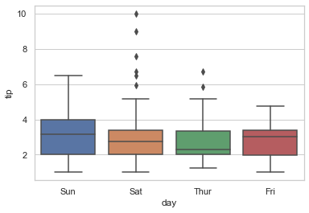

```python
import seaborn as sns
sns.boxplot(x='day', y='tip', data=tips);
```

#### Commentaries

- *By looking at the graphs, we see that the blue box, or Sunday, has the widest spread of tip values. On Saturday, we get a lot of outlier values with a maximum tip value here of 10. Also, just by looking at the lines bisecting the boxes, we could see that the Sunday and Friday have the highest median while Thursday has the lowest.*

Let’s validate this by using another exploratory command: **median**.

```python
tips.groupby(tips.day).median()
```

| day | total_bill | tip | size |
| --- | --- | --- | --- |
| Fri | 15.38 | 3.000 | 2.0 |
| Sat | 18.24 | 2.750 | 2.0 |
| Sun | 19.63 | 3.150 | 2.0 |
| Thur | 16.20 | 2.305 | 2.0 |

We see that the highest median tip is indeed on Sundays, followed by Friday, and then Saturday and then Thursday. Now let’s review the command and learn two new commands: groupby and median. Here, groupby is telling pandas to group the dataframe by the attribute “day” which we specify by putting tips.day inside the parenthesis. If you’re familiar with SQL, groupby() acts like the GROUP BY command in SQL.

You can also do the group by trick with other exploratory commands like describe().

```python
tips.groupby(tips.day).describe()
```

| day | total_bill count | total_bill mean | total_bill std | total_bill min | total_bill 25% | total_bill 50% | total_bill 75% | total_bill max | tip count | tip mean | tip ... | tip 75% | tip max | size count | size mean | size std | size min | size 25% | size 50% | size 75% | size max |
| --- | --- | --- | --- | --- | --- | --- | --- | --- | --- | --- | --- | --- | --- | --- | --- | --- | --- | --- | --- | --- | --- |
| Fri | 19.0 | 17.151579 | 8.302660 | 5.75 | 12.0950 | 15.38 | 21.7500 | 40.17 | 19.0 | 2.734737 | ... | 3.3650 | 4.73 | 19.0 | 2.105263 | 0.567131 | 1.0 | 2.0 | 2.0 | 2.0 | 4.0 |
| Sat | 87.0 | 20.441379 | 9.480419 | 3.07 | 13.9050 | 18.24 | 24.7400 | 50.81 | 87.0 | 2.993103 | ... | 3.3700 | 10.00 | 87.0 | 2.517241 | 0.819275 | 1.0 | 2.0 | 2.0 | 3.0 | 5.0 |
| Sun | 76.0 | 21.410000 | 8.832122 | 7.25 | 14.9875 | 19.63 | 25.5975 | 48.17 | 76.0 | 3.255132 | ... | 4.0000 | 6.50 | 76.0 | 2.842105 | 1.007341 | 2.0 | 2.0 | 2.0 | 4.0 | 6.0 |
| Thur | 62.0 | 17.682742 | 7.886170 | 7.51 | 12.4425 | 16.20 | 20.1550 | 43.11 | 62.0 | 2.771452 | ... | 3.3625 | 6.70 | 62.0 | 2.451613 | 1.066285 | 1.0 | 2.0 | 2.0 | 2.0 | 6.0 |

4 rows × 24 columns

Now the table describes the dataset, but organized by day. Okay, now because there are too many columns, Pandas is truncating the results. We want to view the tips amounts only, so we could filter that by editing our code a little. Modify the first part of the code to this: we change this portion on tips and then we type square brackets and enclose that with another pair of square brackets. Then inside the inner most bracket, we type tip in single quotes. So that’is tip without an s in the end because we are selecting the column named “tip”. So this whole thing here tells Pandas, “in the tip dataset, pull only the tip column. Group them by the day attribute and then describe the statistical summaries of the dataset.

```python
tips[['tip']].groupby(tips.day).describe()
```

| day | tip count | tip mean | tip std | tip min | tip 25% | tip 50% | tip 75% | tip max |
| --- | --- | --- | --- | --- | --- | --- | --- | --- |
| Fri | 19.0 | 2.734737 | 1.019577 | 1.00 | 1.9600 | 3.000 | 3.3650 | 4.73 |
| Sat | 87.0 | 2.993103 | 1.631014 | 1.00 | 2.0000 | 2.750 | 3.3700 | 10.00 |
| Sun | 76.0 | 3.255132 | 1.234880 | 1.01 | 2.0375 | 3.150 | 4.0000 | 6.50 |
| Thur | 62.0 | 2.771452 | 1.240223 | 1.25 | 2.0000 | 2.305 | 3.3625 | 6.70 |

## Visual EDA: Violin Plots

Now, we are going to level up and use the violin plot, a richer, more helpful tool for visual EDA. Violin plots are visual aid for visual exploratory data analysis.

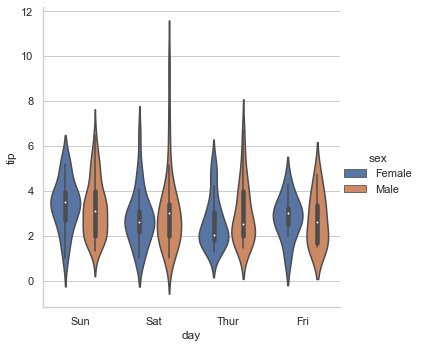

```python
# category plot
# sns.set()
sns.catplot(x='day',y='tip',hue='sex',kind='violin', data = tips) # The hue=”sex” parameter tells  seaborn to use different colors  depending on the sex – Male or Female.
```

The legend here says blue is for Female and this orange color is for Male. This looks a bit messy -- we have 8 plots separating the Male and Female data.  
Let’s simplify it by merging the male and female graphs together. To do this, we’ll add the split parameter parenthesis. Let’s insert the split parameter, like this

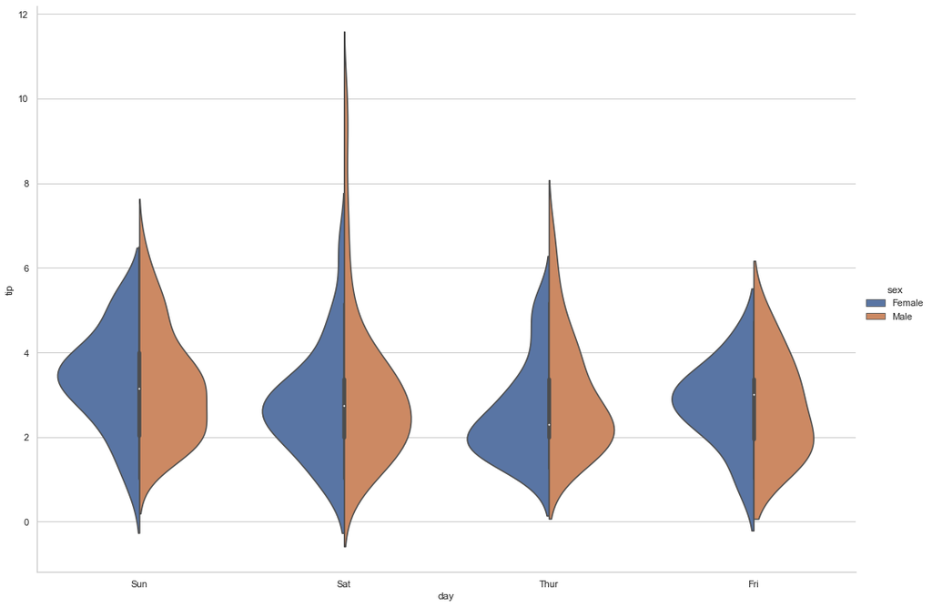

```python
sns.set_style('whitegrid')
sns.catplot(x="day", y="tip", hue="sex", kind="violin", split=True, height=10, aspect = 11.7/8.27, data=tips);
```

# Exploring Dimensions – Category Plots

In this lesson, we will explore the dataset using various methods available in Seaborn. In Tableau, we learned that another way to enrich our exploration is by visualizing the effect of other dimensions like **seasonality, profit, and location**. Today, we will learn about how to visualize dimensions using Jupyter Notebooks, so we could see the data from different perspectives. To do this, we will use **color**, **size**, **shape**, and **positioning** in the plot.

```python
import pandas as pd, seaborn as sns

tips = pd.read_csv('tips.csv') # Read our CSV file and name it 'tips'
tips # Display the dataframe
```

|  | total_bill | tip | sex | smoker | day | time | size |
| --- | --- | --- | --- | --- | --- | --- | --- |
| 0 | 16.99 | 1.01 | Female | No | Sun | Dinner | 2 |
| 1 | 10.34 | 1.66 | Male | No | Sun | Dinner | 3 |
| 2 | 21.01 | 3.50 | Male | No | Sun | Dinner | 3 |
| 3 | 23.68 | 3.31 | Male | No | Sun | Dinner | 2 |
| 4 | 24.59 | 3.61 | Female | No | Sun | Dinner | 4 |
| ... | ... | ... | ... | ... | ... | ... | ... |
| 239 | 29.03 | 5.92 | Male | No | Sat | Dinner | 3 |
| 240 | 27.18 | 2.00 | Female | Yes | Sat | Dinner | 2 |
| 241 | 22.67 | 2.00 | Male | Yes | Sat | Dinner | 2 |
| 242 | 17.82 | 1.75 | Male | No | Sat | Dinner | 2 |
| 243 | 18.78 | 3.00 | Female | No | Thur | Dinner | 2 |

244 rows × 7 columns

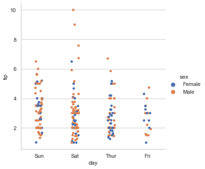

```python
sns.catplot(data = tips, x='day', y='tip', hue='sex', );
```

Now let’s tweak our visuals and explore other dimensions.

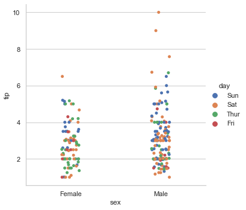

```python
sns.catplot(data = tips, x='sex', y='tip', hue='day', );
```

We could see right away there are more Male customers giving tips and they have the highest ones, as we saw in the previous visual. It’s a bit hard to distinguish which day has the most number of tips but we could actually just scroll up in previous chart to see the plot using day as dimension. Plotting the points using different dimensions, you could discover more information out of the dataset. Let’s do it again.

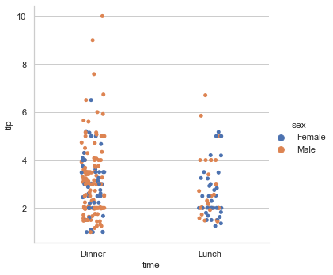

```python
sns.catplot(data = tips, x='time', y='tip', hue='sex', );
```

So what we did here is to plot the time of the meal and that’s just Lunch and Dinner..you could see that there are more dots at Dinner time. Let’s do one more.

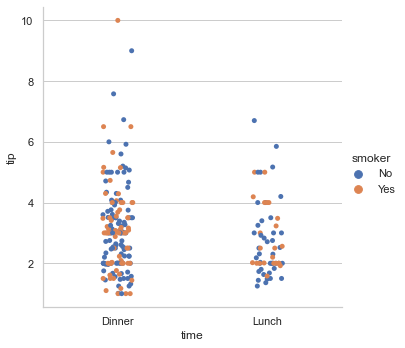

```python
sns.catplot(data = tips, x='time', y='tip', hue='smoker', );
```

Here, at Dinner and Lunch time, it looks like Non-smokers tend to give higher tips. Here is the maximum tip value of 10 and it was given by a smoker. If we scroll  
up to the previous visual, we know that this high tipper-smoker is also Male. So you see how viewing data from multiple dimensions creates more insight about the information.

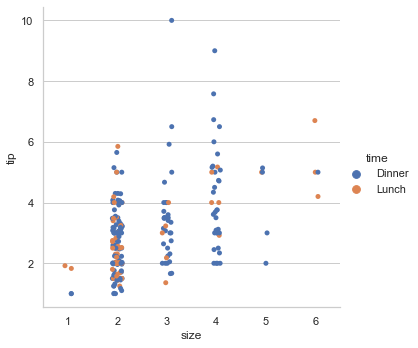

```python
sns.catplot(data = tips, x='size', y='tip', hue='time', );
```

What we could see now is that the highest tip of 10 came from a table of 3. Most of the other high tip amounts came from a table for 4.  
There seems to be a general trend where the larger the table size, the larger the tip, of course this could be because tips are sometimes calculated as a percent of the total bill, when you have a larger table size then you will have a larger total bill. … It seems to be the case from table size 2, 3, 4, the sizes… they seem to generally increase in tip size… there’s also this one high tip from table 6. But at a size of 5, this trend seems not to apply. This is just from visually inspecting the plots and you should verify this using other methods, like regression perhaps. You’ve just learned how to configure catplots or category plots to highlight various dimensions in the dataset.